# Word Prediction Algorithm: Exploratory Analysis

Oliver Stroemer

2020-04-07

## Synopsis

This report aims to give me a brief exploratory overview of the English part of the course corpus, before I start designing the prediction algorithm.

Since the full data set is really huge, I will for now only look at a subset of the data. 50K lines of each set should suffice to get a brief overview.

I use the `tidytext` package to split the corpora into n-grams and analyze the frequencies of their occurrences.

## Analyzing length of data entries

Let us first have a look at the length of the entries in characters.

```
## # A tibble: 3 x 5
##   sets      min median  mean   max
##   <chr>   <int>  <dbl> <dbl> <int>
## 1 blogs       2    156 230.   6887
## 2 news        3    186 202.   2757
## 3 twitter     5     65  69.6   141
```

This is really interesting. The twitter data seems to be from the time, when tweets were limited to 140 characters. Why is there at least one tweet with 141 characters? The files are in DOS-format, which means that there is an additional carriage return character at the end of each line. The line sampling function does not account for this fact.

## Analyzing Single Words

This is how many words we have to deal with:

```
## [1] "Words: 4434235"
```

[output not shown]

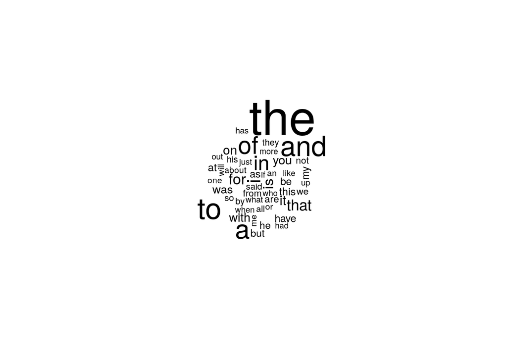

Unsurprisingly the top 50 words are all stop words.

Let us now have a look at how many unique words we need to cover 50 % and 90 % of the corpus.

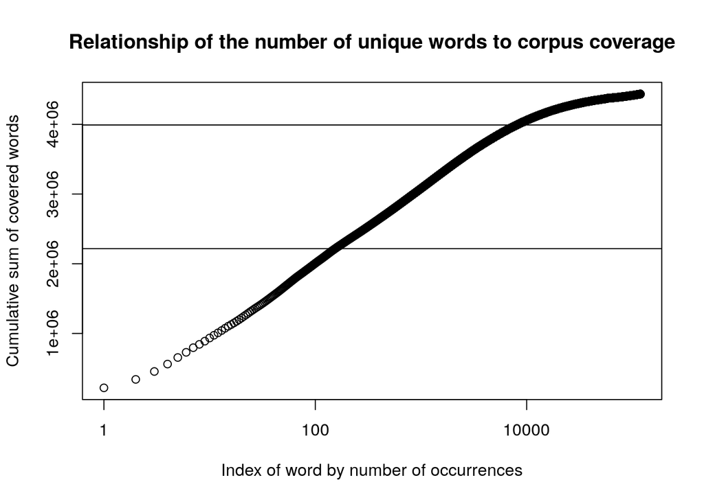

We see, the bigger part of our unique words does not really add much to our overall coverage. This is something I need to keep in mind, when I design the prediction model.

## Analyzing Bi- and Trigrams

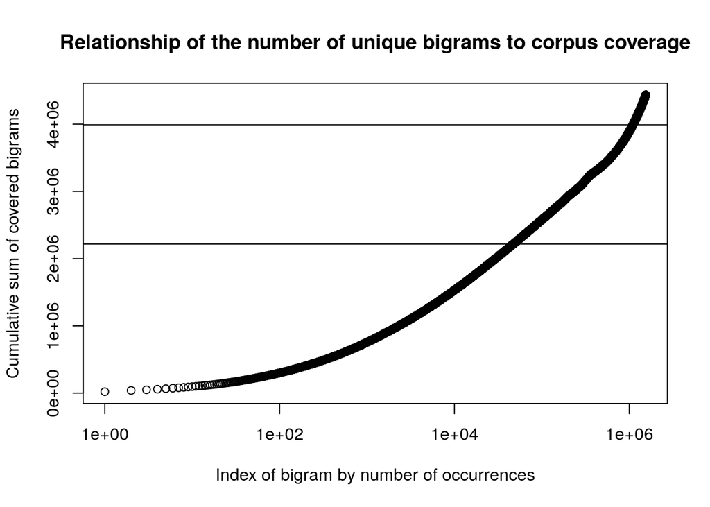

Wow… They are many. Unlike with the single words, we need close to a million unique bigrams to cover 90 % of our corpus. I expect this to become even worse if we look at our trigrams. Because of the long computation time needed, I use a smaller subset of only 30 % of the previous corpus.

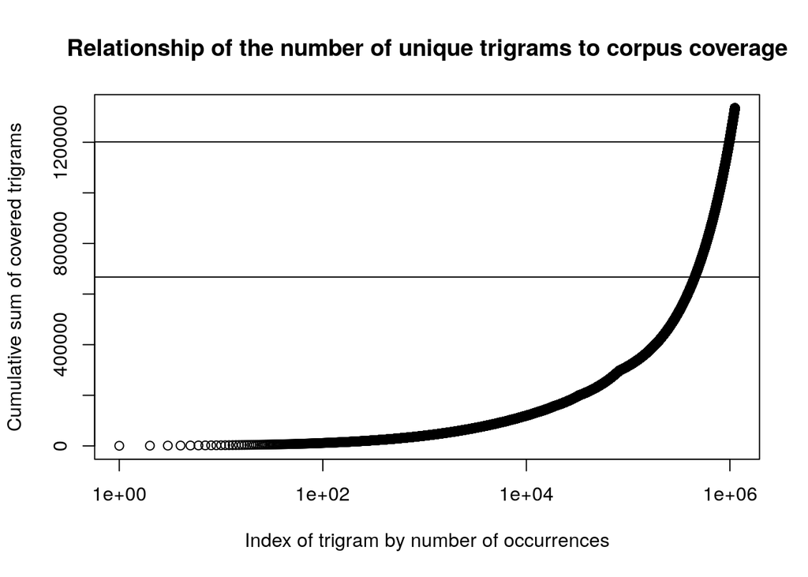

As predicted, the impact of each new trigram, which we add to our pool, becomes rapidly smaller and smaller. Luckily we can eliminate some of the trigrams in our model, because we only need the prediction with the highest probability.

## Conclusions and Prospect

I will use a n-gram based prediction algorithm. Most importantly I need to reduce the number of n-grams in the pool while preserving as much accuracy as possible.

The model must not predict any profanity words. There are R packages like `sentimentr` that provide dictionaries which I can use to filter such predictions.

## References

Silge & Robinson (2020) *Text Mining with R* https://www.tidytextmining.com/